# LAB 6: Traditional Regression and Model Selection

Stephanie Liu

11/5/2021

```r
library(tidyverse)
library(here)
library(tidymodels)
options(scipen = 99)
```

# Part One: Data Exploration

#### The dataset we will study for this assignment contains information about health insurance costs for individuals with no dependents (children) in the United States. The information contained in the data is:

- Age of primary beneficiary
- Gender of primary beneficiary (only female, male recorded)
- Body mass index, providing an understanding of body, weights that are relatively high or low relative to height, objective index of body weight (kg / m ^ 2) using the ratio of height to weight, ideally 18.5 to 24.9
- Whether the beneficiary smokes
- The beneficiary’s residential area in the US, northeast, southeast, southwest, northwest.
- Individual medical costs billed by health insurance

#### You can find this data at: https://www.dropbox.com/s/bocjjyo1ehr5auz/insurance_costs_1.csv?dl=1

#### 1. Read in the dataset, and display some summaries of the data.

```r
insurance1 <- read_csv(here("Data", "insurance_costs_1.csv"))
summary(insurance1)
```

```
##       age            sex                 bmi           smoker
##  Min.   :18.00   Length:431         Min.   :15.96   Length:431
##  1st Qu.:22.00   Class :character   1st Qu.:26.36   Class :character
##  Median :34.00   Mode  :character   Median :30.59   Mode  :character
##  Mean   :37.96                      Mean   :30.77
##  3rd Qu.:55.00                      3rd Qu.:35.27
##  Max.   :64.00                      Max.   :49.06
##     region             charges
##  Length:431         Min.   : 1132
##  Class :character   1st Qu.: 2710
##  Mode  :character   Median : 9866
##                     Mean   :12297
##                     3rd Qu.:14511
##                     Max.   :55135
```

```r
insurance1 %>%
  group_by(region) %>%
  summarise(mean(age), mean(bmi), mean(charges))
```

```
## # A tibble: 4 × 4
##   region    `mean(age)` `mean(bmi)` `mean(charges)`
##   <chr>           <dbl>       <dbl>           <dbl>
## 1 northeast        38.8        29.7          11985.
## 2 northwest        37.0        29.0          11097.
## 3 southeast        37.3        33.7          13917.
## 4 southwest        38.7        30.0          11765.
```

```r
insurance1 %>%
  group_by(sex) %>%
  summarise(mean(age), mean(bmi), mean(charges))
```

```
## # A tibble: 2 × 4
##   sex    `mean(age)` `mean(bmi)` `mean(charges)`
##   <chr>        <dbl>       <dbl>           <dbl>
## 1 female        37.7        30.9          11919.
## 2 male          38.3        30.6          12710.
```

```r
insurance1 %>%
  group_by(smoker) %>%
  summarise(mean(age), mean(bmi), mean(charges))
```

```
## # A tibble: 2 × 4
##   smoker `mean(age)` `mean(bmi)` `mean(charges)`
##   <chr>        <dbl>       <dbl>           <dbl>
## 1 no            38.3        30.8           7528.
## 2 yes           36.6        30.7          31152.
```

In this dataset, There are 4 regions: northeast, northwest, southeast, and southwest.

There are two sexes: male and female

There are smokers and non-smokers.

The minimum age is 18 years old and the maximum age is 64 years old, and the mean age is 37.96 years old.

The minimum BMI is 15.96 and the maximum BMI is 49.06, and the mean BMI is 30.77.

The minimum hospital charge is $\$1132$ and the maximum is $\$55135$.

#### 2. Fix any concerns you have about the data.

```r
insurance1_clean <- insurance1 %>%
  mutate(sex = as.factor(sex),
         smoker = as.factor(smoker),
         region = as.factor(region))
```

#### 3. Make up to three plots comparing the response variable (charges) to one of the predictor variables. Briefly discuss each plot.

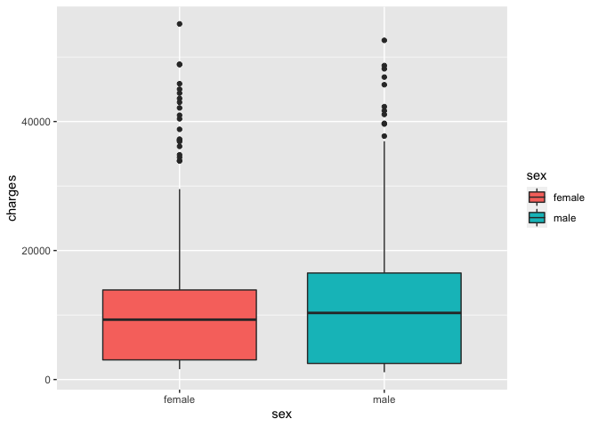

```r
insurance1_clean %>%
  ggplot(aes(x = sex, y = charges)) +
  geom_boxplot(aes(fill = sex))
```

On average, the medical charges for males and females are about the same. Males may have slightly higher charges than females, but not by much.

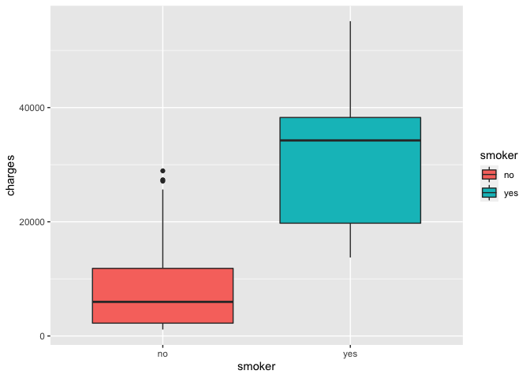

```r
insurance1_clean %>%
  ggplot(aes(x = smoker, y = charges)) +
  geom_boxplot(aes(fill = smoker))
```

The medical charges for smokers are much higher than for non-smokers.

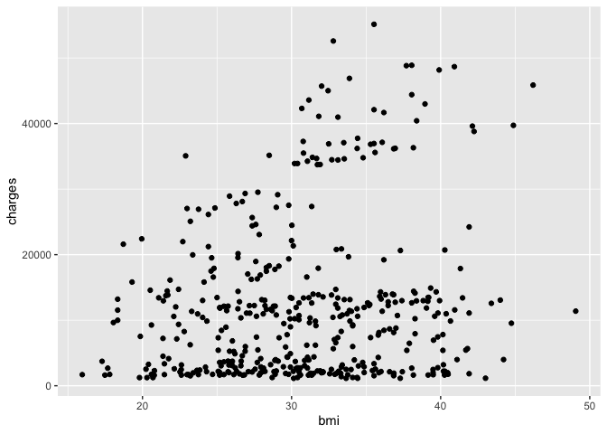

```r
insurance1_clean %>%
  ggplot(aes(x = bmi, y = charges)) +
  geom_point()
```

The plot is somewhat spread out, but in general, those with high BMI (> 30) have much higher medical charges (> 30000) than those with lower BMI (in the ideal range between 18.5 and 24.9).

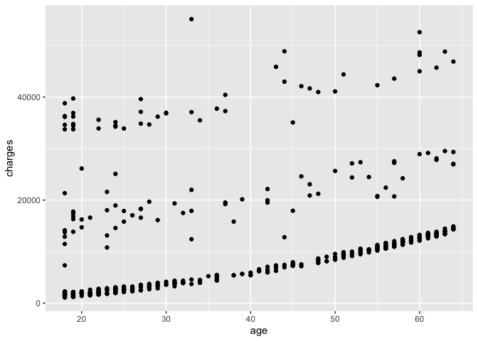

```r
insurance1_clean %>%
  ggplot(aes(x = age, y = charges)) +
  geom_point()
```

It seems that people of younger ages have (generally) lower medical charges than those who are older (50+ years). There seems to be three trend lines among this plot (this may be due to other factors like whether or not someone smokes, or has other medical issues).

# Part Two: Simple Linear Models

#### 1. Construct a simple linear model to predict the insurance `charges` from the beneficiary’s `age`. Discuss the model fit, and interpret the coefficient estimates.

```r
lr_mod_spec <- linear_reg() %>%
  set_mode("regression") %>%
  set_engine("lm")

rec <- recipe(charges ~ age, data = insurance1_clean)

wflow <- workflow() %>%
  add_model(lr_mod_spec) %>%
  add_recipe(rec)

model_fit <- wflow %>%
  fit(insurance1_clean)

wflow_fit <- model_fit %>%
  extract_fit_parsnip()

wflow_fit$fit %>%
  summary()
```

```
##
## Call:
## stats::lm(formula = ..y ~ ., data = data)
##
## Residuals:
##    Min     1Q Median     3Q    Max
##  -7458  -6490  -5628   4154  43973
##
## Coefficients:
##             Estimate Std. Error t value        Pr(>|t|)
## (Intercept)  3611.76    1374.39   2.628          0.0089 **
## age           228.80      33.25   6.880 0.0000000000212 ***
## ---
## Signif. codes:  0 '***' 0.001 '**' 0.01 '*' 0.05 '.' 0.1 ' ' 1
##
## Residual standard error: 11280 on 429 degrees of freedom
## Multiple R-squared:  0.09938,    Adjusted R-squared:  0.09728
## F-statistic: 47.34 on 1 and 429 DF,  p-value: 0.00000000002124
```

$\widehat{charges} = 3611.76 + 228.80 * age$

For every one year increase in age, the average medical charge increases by $\$228.80$.

$R^2 = 0.09938$, Adjusted $R^2 = 0.0972$

9.72% of the variation in charges is explained by the model (the predictor age).

Since the $R^2$ value is fairly low, this may not be the best fit model for the data.

#### 2. Make a model that also incorporates the variable `sex`. Report your results.

```r
lr_mod_spec <- linear_reg() %>%
  set_mode("regression") %>%
  set_engine("lm")

# Note that this recipe will automatically set female to be the reference level for the sex variable
rec2 <- recipe(charges ~ age + sex, data = insurance1_clean)

wflow2 <- workflow() %>%
  add_model(lr_mod_spec) %>%
  add_recipe(rec2)

model_fit2 <- wflow2 %>%
  fit(insurance1_clean)

wflow_fit2 <- model_fit2 %>%
  extract_fit_parsnip()

wflow_fit2$fit %>%
  summary()
```

```
##
## Call:
## stats::lm(formula = ..y ~ ., data = data)
##
## Residuals:
##    Min     1Q Median     3Q    Max
##  -7799  -6472  -5586   4177  44282
##
## Coefficients:
##             Estimate Std. Error t value        Pr(>|t|)
## (Intercept)  3315.33    1462.40   2.267          0.0239 *
## age           228.43      33.28   6.863 0.0000000000238 ***
## sexmale       649.83    1089.14   0.597          0.5511
## ---
## Signif. codes:  0 '***' 0.001 '**' 0.01 '*' 0.05 '.' 0.1 ' ' 1
##
## Residual standard error: 11290 on 428 degrees of freedom
## Multiple R-squared:  0.1001, Adjusted R-squared:  0.09592
## F-statistic: 23.81 on 2 and 428 DF,  p-value: 0.0000000001565
```

$\widehat{charges} = 3315.33 + 228.43 * age + 649.83 * male$

For every one year increase in age, the average medical charge increases by $\$228.43$, adjusting for the other terms in the model.

For males, the average medical charge is $\$649.83$ more than females, adjusting for the other terms in the model.

$R^2 = 0.1001$, Adjusted $R^2 = 0.09592$

9.59% of the variation in charges is explained by the model (the predictors age and sex).

Since the Adjusted $R^2$ value is fairly low, this may not be the best fit model for the data.

#### 3. Now make a model that does not include sex, but does include smoker. Report your results.

```r
lr_mod_spec <- linear_reg() %>%
  set_mode("regression") %>%
  set_engine("lm")

# Note that this recipe will automatically set non-smokers to be the reference level for the smoker variable
rec3 <- recipe(charges ~ age + smoker, data = insurance1_clean)

wflow3 <- workflow() %>%
  add_model(lr_mod_spec) %>%
  add_recipe(rec3)

model_fit3 <- wflow3 %>%
  fit(insurance1_clean)

wflow_fit3 <- model_fit3 %>%
  extract_fit_parsnip()

wflow_fit3$fit %>%
  summary()
```

```
##
## Call:
## stats::lm(formula = ..y ~ ., data = data)
##
## Residuals:
##      Min       1Q   Median       3Q      Max
## -15680.8  -1730.8  -1020.7   -174.2  24899.6
##
## Coefficients:
##             Estimate Std. Error t value             Pr(>|t|)
## (Intercept) -2166.85     729.40  -2.971              0.00314 **
## age           253.15      17.19  14.729 < 0.0000000000000002 ***
## smokeryes   24048.87     699.89  34.361 < 0.0000000000000002 ***
## ---
## Signif. codes:  0 '***' 0.001 '**' 0.01 '*' 0.05 '.' 0.1 ' ' 1
##
## Residual standard error: 5827 on 428 degrees of freedom
## Multiple R-squared:  0.7604, Adjusted R-squared:  0.7593
## F-statistic: 679.1 on 2 and 428 DF,  p-value: < 0.00000000000000022
```

$\widehat{charges} = -2166.85 + 253.15 * age + 24048.87 * smoker$

For every one year increase in age, the average medical charge increases by $\$253.15$, adjusting for the other terms in the model.

For smokers, the average medical charge is $\$24048.87$ more than non-smokers, adjusting for the other terms in the model.

$R^2 = 0.7604$, Adjusted $R^2 = 0.7593$

75.93% of the variation in charges is explained by the model (the predictors age and smoker).

Since the Adjusted $R^2$ value is much higher, this may be a better fit model for the data.

#### 4. Which model (Q2 or Q3) do you think better fits the data? Justify your answer by calculating the MSE for each model, and also by comparing R-squared values.

Model2: $R^2 = 0.1001$, Adjusted $R^2 = 0.09592$

```r
# MSE
mean((summary(wflow_fit2$fit)$residuals)^2)
```

```
## [1] 126633940
```

Model3: $R^2 = 0.7604$, Adjusted $R^2 = 0.7593$

```r
mean((summary(wflow_fit3$fit))$residuals^2)
```

```
## [1] 33719831
```

Model3 has the largest $R^2$ and Adjusted $R^2$ values, as well as the smaller mean square error. Therefore, we can say Model3 is the better fit model for the data.

# Part Three: Multiple Linear Models

#### Now let’s consider including multiple quantitative predictors.

#### 1. Fit a model that uses age and bmi as predictors. (Do not include an interaction term between these two.) Report your results. How does the MSE compare to the model in Part Two Q1? How does the Adjusted R-squared compare?

```r
lr_mod_spec <- linear_reg() %>%
  set_mode("regression") %>%
  set_engine("lm")

rec4 <- recipe(charges ~ age + bmi, data = insurance1_clean)

wflow4 <- workflow() %>%
  add_model(lr_mod_spec) %>%
  add_recipe(rec4)

model_fit4 <- wflow4 %>%
  fit(insurance1_clean)

wflow_fit4 <- model_fit4 %>%
  extract_fit_parsnip()

wflow_fit4$fit %>%
  summary()
```

```
##
## Call:
## stats::lm(formula = ..y ~ ., data = data)
##
## Residuals:
##    Min     1Q Median     3Q    Max
## -10823  -6716  -4979   3309  42563
##
## Coefficients:
##             Estimate Std. Error t value       Pr(>|t|)
## (Intercept) -4627.53    2917.60  -1.586        0.11346
## age           216.30      33.14   6.528 0.000000000189 ***
## bmi           283.20      88.73   3.192        0.00152 **
## ---
## Signif. codes:  0 '***' 0.001 '**' 0.01 '*' 0.05 '.' 0.1 ' ' 1
##
## Residual standard error: 11170 on 428 degrees of freedom
## Multiple R-squared:  0.1203, Adjusted R-squared:  0.1162
## F-statistic: 29.27 on 2 and 428 DF,  p-value: 0.000000000001217
```

$\widehat{charges} = -4627.53 + 216.30 * age + 283.20 * bmi$

For every one year increase in age, the average medical charge increases by $\$216.30$, adjusting for the other terms in the model.

For every 1 kg/m^2 increase in BMI, the average medical charge increases by $\$283.20$, adjusting for the other terms in the model.

$R^2 = 0.1203$, Adjusted $R^2 = 0.1162$

11.62% of the variation in charges is explained by the model (the predictors age and BMI).

The Adjusted $R^2$ value is slightly higher than it was for the model in part 2 Q1 (model1).

```r
mean((summary(wflow_fit$fit))$residuals^2)
```

```
## [1] 126739268
```

```r
mean((summary(wflow_fit4$fit))$residuals^2)
```

```
## [1] 123792440
```

The mean square error for Model1 (part 2 Q1) is slightly higher than the MSE for Model4 (part 3 Q1).

#### 2. Perhaps the relationships are not linear. Fit a model that uses age and age^2 as predictors. How do the MSE and R-squared compare to the model in P2 Q1?

Hint: You can do this by using the poly() function

```r
lr_mod_spec <- linear_reg() %>%
  set_mode("regression") %>%
  set_engine("lm")

rec5 <- recipe(charges ~ age, data = insurance1_clean) %>%
  step_poly(age, degree = 2)

wflow5 <- workflow() %>%
  add_model(lr_mod_spec) %>%
  add_recipe(rec5)

model_fit5 <- wflow5 %>%
  fit(insurance1_clean)

wflow_fit5 <- model_fit5 %>%
  extract_fit_parsnip()

wflow_fit5$fit %>%
  summary()
```

```
##
## Call:
## stats::lm(formula = ..y ~ ., data = data)
##
## Residuals:
##    Min     1Q Median     3Q    Max
##  -7705  -6521  -5660   4173  43748
##
## Coefficients:
##             Estimate Std. Error t value             Pr(>|t|)
## (Intercept)  12297.1      544.1  22.601 < 0.0000000000000002 ***
## age_poly_1   77638.2    11295.9   6.873      0.0000000000223 ***
## age_poly_2   -3533.8    11295.9  -0.313                0.755
## ---
## Signif. codes:  0 '***' 0.001 '**' 0.01 '*' 0.05 '.' 0.1 ' ' 1
##
## Residual standard error: 11300 on 428 degrees of freedom
## Multiple R-squared:  0.09959,    Adjusted R-squared:  0.09538
## F-statistic: 23.67 on 2 and 428 DF,  p-value: 0.000000000178
```

$\widehat{charges} = 12297.1 + 77638.2 * age - 3533.8 * age^2$

$R^2 = 0.09959$, Adjusted $R^2 = 0.09538$

9.538% of the variation in charges is explained by the model (the predictors age and age^2).

The Adjusted $R^2$ value is about the same (slightly lower) as it was for the model in part 2 Q1 (Model1).

```r
mean((summary(wflow_fit$fit))$residuals^2)
```

```
## [1] 126739268
```

```r
mean((summary(wflow_fit5$fit))$residuals^2)
```

```
## [1] 126710294
```

The mean square error for Model1 (part 2 Q1) is only slightly higher than the MSE for Model5 (part 3 Q2).

#### 3. Fit a polynomial model of degree 4. How do the MSE and R-squared compare to the model in P2 Q1?

```r
lr_mod_spec <- linear_reg() %>%
  set_mode("regression") %>%
  set_engine("lm")

rec6 <- recipe(charges ~ age, data = insurance1_clean) %>%
  step_poly(age, degree = 4)

wflow6 <- workflow() %>%
  add_model(lr_mod_spec) %>%
  add_recipe(rec6)

model_fit6 <- wflow6 %>%
  fit(insurance1_clean)

wflow_fit6 <- model_fit6 %>%
  extract_fit_parsnip()

wflow_fit6$fit %>%
  summary()
```

```
##
## Call:
## stats::lm(formula = ..y ~ ., data = data)
##
## Residuals:
##    Min     1Q Median     3Q    Max
##  -9314  -6435  -5354   4639  42680
##
## Coefficients:
##             Estimate Std. Error t value             Pr(>|t|)
## (Intercept)  12297.1      542.9  22.652 < 0.0000000000000002 ***
## age_poly_1   77638.2    11270.5   6.889      0.0000000000203 ***
## age_poly_2   -3533.8    11270.5  -0.314               0.7540
## age_poly_3    8004.1    11270.5   0.710               0.4780
## age_poly_4   20877.1    11270.5   1.852               0.0647 .
## ---
## Signif. codes:  0 '***' 0.001 '**' 0.01 '*' 0.05 '.' 0.1 ' ' 1
##
## Residual standard error: 11270 on 426 degrees of freedom
## Multiple R-squared:  0.1078, Adjusted R-squared:  0.09945
## F-statistic: 12.87 on 4 and 426 DF,  p-value: 0.0000000006684
```

$\widehat{charges} = 12297.1 + 77638.2 * age - 3533.8 * age^2 + 8004.1 * age^3 + 20877.1 * age^4$

$R^2 = 0.1078$, Adjusted $R^2 = 0.09945$

9.945% of the variation in charges is explained by the model.

The Adjusted $R^2$ value is about the same (slightly higher) as it was for the model in part 2 Q1 (Model1).

```r
mean((summary(wflow_fit$fit))$residuals^2)
```

```
## [1] 126739268
```

```r
mean((summary(wflow_fit6$fit))$residuals^2)
```

```
## [1] 125550390
```

The mean square error for Model1 (part 2 Q1) is a little higher than the MSE for Model6 (part 3 Q3).

#### 4. Fit a polynomial model of degree 12. How do the MSE and R-squared compare to the model in P2 Q1?

```r
lr_mod_spec <- linear_reg() %>%
  set_mode("regression") %>%
  set_engine("lm")

rec7 <- recipe(charges ~ age, data = insurance1_clean) %>%
  step_poly(age, degree = 12)

wflow7 <- workflow() %>%
  add_model(lr_mod_spec) %>%
  add_recipe(rec7)

model_fit7 <- wflow7 %>%
  fit(insurance1_clean)

wflow_fit7 <- model_fit7 %>%
  extract_fit_parsnip()

wflow_fit7$fit %>%
  summary()
```

```
##
## Call:
## stats::lm(formula = ..y ~ ., data = data)
##
## Residuals:
##    Min     1Q Median     3Q    Max
## -10120  -6922  -4672   3492  42482
##
## Coefficients:
##             Estimate Std. Error t value             Pr(>|t|)
## (Intercept)  12297.1      544.5  22.586 < 0.0000000000000002 ***
## age_poly_1   77638.2    11303.3   6.869      0.0000000000236 ***
## age_poly_2   -3533.8    11303.3  -0.313               0.7547
## age_poly_3    8004.1    11303.3   0.708               0.4793
## age_poly_4   20877.1    11303.3   1.847               0.0655 .
## age_poly_5    -696.6    11303.3  -0.062               0.9509
## age_poly_6    4306.6    11303.3   0.381               0.7034
## age_poly_7  -11402.9    11303.3  -1.009               0.3137
## age_poly_8   -4046.7    11303.3  -0.358               0.7205
## age_poly_9   12243.0    11303.3   1.083               0.2794
## age_poly_10   6463.8    11303.3   0.572               0.5677
## age_poly_11  12674.0    11303.3   1.121               0.2628
## age_poly_12 -13734.5    11303.3  -1.215               0.2250
## ---
## Signif. codes:  0 '***' 0.001 '**' 0.01 '*' 0.05 '.' 0.1 ' ' 1
##
## Residual standard error: 11300 on 418 degrees of freedom
## Multiple R-squared:  0.1195, Adjusted R-squared:  0.0942
## F-statistic: 4.726 on 12 and 418 DF,  p-value: 0.0000002951
```

$R^2 = 0.1195$, Adjusted $R^2 = 0.0942$

9.42% of the variation in charges is explained by the model.

The Adjusted $R^2$ value is about the same (slightly lower) as it was for the model in part 2 Q1 (Model1).

```r
mean((summary(wflow_fit$fit))$residuals^2)
```

```
## [1] 126739268
```

```r
mean((summary(wflow_fit7$fit))$residuals^2)
```

```
## [1] 123911481
```

The mean square error for Model1 (part 2 Q1) is higher than the MSE for Model7 (part 3 Q4).

#### 5. According to the MSE and R-squared, which is the best model? Do you agree that this is indeed the “best” model? Why or why not?

Model1:

```r
# Adj R Sq
summary(wflow_fit$fit)$adj.r.square
```

```
## [1] 0.09728171
```

```r
# MSE
mean((summary(wflow_fit$fit))$residuals^2)
```

```
## [1] 126739268
```

Model2:

```r
# Adj R Sq
summary(wflow_fit2$fit)$adj.r.square
```

```
## [1] 0.09592452
```

```r
# MSE
mean((summary(wflow_fit2$fit))$residuals^2)
```

```
## [1] 126633940
```

Model3:

```r
# Adj R Sq
summary(wflow_fit3$fit)$adj.r.square
```

```
## [1] 0.7592646
```

```r
# MSE
mean((summary(wflow_fit3$fit))$residuals^2)
```

```
## [1] 33719831
```

Model 3 has the highest Adjusted $R^2$ and lowest MSE. Overall, this is the “best” model. This makes sense, as it includes predictors age and smoker, which both likely have effects on hospital charges.

Model4:

```r
# Adj R Sq
summary(wflow_fit4$fit)$adj.r.square
```

```
## [1] 0.1162108
```

```r
# MSE
mean((summary(wflow_fit4$fit))$residuals^2)
```

```
## [1] 123792440
```

Model5:

```r
# Adj R Sq
summary(wflow_fit5$fit)$adj.r.square
```

```
## [1] 0.09537941
```

```r
# MSE
mean((summary(wflow_fit5$fit))$residuals^2)
```

```
## [1] 126710294
```

Model6:

```r
# Adj R Sq
summary(wflow_fit6$fit)$adj.r.square
```

```
## [1] 0.09945212
```

```r
# MSE
mean((summary(wflow_fit6$fit))$residuals^2)
```

```
## [1] 125550390
```

Model7:

```r
# Adj R Sq
summary(wflow_fit7$fit)$adj.r.square
```

```
## [1] 0.09419731
```

```r
# MSE
mean((summary(wflow_fit7$fit))$residuals^2)
```

```
## [1] 123911481
```

For just the models in Part 3, Model4 has the highest adjusted $R^2$ and lowest MSE. So, from the last four models, Model4 (with predictors age and BMI) was the “best” model. This makes sense, as it includes two predictors, age and BMI, which should both have some effect of hospital charges.

#### 6. Plot the predictions from your model in Q4 as a line plot on top of the scatterplot of your original data.

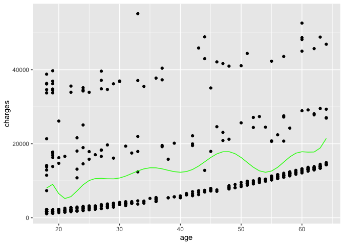

```r
preds <- predict(model_fit7, insurance1_clean)

new_data <- cbind(insurance1_clean, preds)

new_data %>%
  ggplot() +
  geom_point(aes(x = age, y = charges)) +
  geom_line(aes(x = age, y = .pred), color = "green")
```

# Part Four: New data

#### Great news! We’ve managed to collect data about the insurance costs for a few more individuals. You can find the new dataset here: https://www.dropbox.com/s/sky86agc4s8c6qe/insurance_costs_2.csv?dl=1

```r
insurance2 <- read_csv(here("Data", "insurance_costs_2.csv"))
summary(insurance2)
```

```
##       age           sex                 bmi           smoker
##  Min.   :18.0   Length:143         Min.   :18.60   Length:143
##  1st Qu.:21.5   Class :character   1st Qu.:25.48   Class :character
##  Median :42.0   Mode  :character   Median :29.30   Mode  :character
##  Mean   :39.9                      Mean   :29.89
##  3rd Qu.:56.0                      3rd Qu.:33.49
##  Max.   :64.0                      Max.   :53.13
##     region             charges
##  Length:143         Min.   : 1122
##  Class :character   1st Qu.: 3073
##  Mode  :character   Median : 9635
##                     Mean   :12574
##                     3rd Qu.:14270
##                     Max.   :63770
```

```r
insurance2 <- insurance2 %>%
  mutate(sex = as.factor(sex),
         smoker = as.factor(smoker),
         region = as.factor(region))
```

#### Consider the following possible models:

- Only age as a predictor.
- age and bmi as a predictor.
- age, bmi, and smoker as predictors (no interaction terms)
- age, and bmi, with both quantitative variables having an interaction term with smoker (i.e. the formula ~ (age + bmi):smoker)
- age, bmi, and smoker as predictors, with both quantitative variables having an interaction term with smoker (i.e. the formula ~ (age + bmi)*smoker)

#### 1. For each model, fit the model on the original data.

Age as predictor:

```r
lr_mod_spec <- linear_reg() %>%
  set_mode("regression") %>%
  set_engine("lm")

med_rec <- recipe(charges ~ age, data = insurance1_clean)

med_wflow <- workflow() %>%
  add_model(lr_mod_spec) %>%
  add_recipe(med_rec)

med_model_fit <- med_wflow %>%
  fit(insurance1_clean)

med_wflow_fit <- med_model_fit %>%
  extract_fit_parsnip()

med_wflow_fit$fit %>%
  summary()
```

```
##
## Call:
## stats::lm(formula = ..y ~ ., data = data)
##
## Residuals:
##    Min     1Q Median     3Q    Max
##  -7458  -6490  -5628   4154  43973
##
## Coefficients:
##             Estimate Std. Error t value        Pr(>|t|)
## (Intercept)  3611.76    1374.39   2.628          0.0089 **
## age           228.80      33.25   6.880 0.0000000000212 ***
## ---
## Signif. codes:  0 '***' 0.001 '**' 0.01 '*' 0.05 '.' 0.1 ' ' 1
##
## Residual standard error: 11280 on 429 degrees of freedom
## Multiple R-squared:  0.09938,    Adjusted R-squared:  0.09728
## F-statistic: 47.34 on 1 and 429 DF,  p-value: 0.00000000002124
```

Age and BMI as predictors:

```r
med_rec2 <- recipe(charges ~ age + bmi, data = insurance1_clean)

med_wflow2 <- workflow() %>%
  add_model(lr_mod_spec) %>%
  add_recipe(med_rec2)

med_model_fit2 <- med_wflow2 %>%
  fit(insurance1_clean)

med_wflow_fit2 <- med_model_fit2 %>%
  extract_fit_parsnip()

med_wflow_fit2$fit %>%
  summary()
```

```
##
## Call:
## stats::lm(formula = ..y ~ ., data = data)
##
## Residuals:
##    Min     1Q Median     3Q    Max
## -10823  -6716  -4979   3309  42563
##
## Coefficients:
##             Estimate Std. Error t value       Pr(>|t|)
## (Intercept) -4627.53    2917.60  -1.586        0.11346
## age           216.30      33.14   6.528 0.000000000189 ***
## bmi           283.20      88.73   3.192        0.00152 **
## ---
## Signif. codes:  0 '***' 0.001 '**' 0.01 '*' 0.05 '.' 0.1 ' ' 1
##
## Residual standard error: 11170 on 428 degrees of freedom
## Multiple R-squared:  0.1203, Adjusted R-squared:  0.1162
## F-statistic: 29.27 on 2 and 428 DF,  p-value: 0.000000000001217
```

Age, BMI, Smoker as predictors:

```r
med_rec3 <- recipe(charges ~ age + bmi + smoker, data = insurance1_clean)

med_wflow3 <- workflow() %>%
  add_model(lr_mod_spec) %>%
  add_recipe(med_rec3)

med_model_fit3 <- med_wflow3 %>%
  fit(insurance1_clean)

med_wflow_fit3 <- med_model_fit3 %>%
  extract_fit_parsnip()

med_wflow_fit3$fit %>%
  summary()
```

```
##
## Call:
## stats::lm(formula = ..y ~ ., data = data)
##
## Residuals:
##      Min       1Q   Median       3Q      Max
## -12449.9  -2613.5   -765.4   1207.0  23502.6
##
## Coefficients:
##              Estimate Std. Error t value             Pr(>|t|)
## (Intercept) -10350.08    1465.99  -7.060     0.00000000000678 ***
## age            240.72      16.56  14.532 < 0.0000000000000002 ***
## bmi            281.32      44.32   6.348     0.00000000055847 ***
## smokeryes    24043.83     669.82  35.896 < 0.0000000000000002 ***
## ---
## Signif. codes:  0 '***' 0.001 '**' 0.01 '*' 0.05 '.' 0.1 ' ' 1
##
## Residual standard error: 5577 on 427 degrees of freedom
## Multiple R-squared:  0.781,  Adjusted R-squared:  0.7795
## F-statistic: 507.7 on 3 and 427 DF,  p-value: < 0.00000000000000022
```

Age, BMI and age x smoker, BMI x smoker as predictors:

```r
med_rec4 <- recipe(charges ~ age + bmi + smoker, data = insurance1_clean) %>%
  step_interact(terms = ~(age + bmi):smoker) %>%
  step_rm(smoker)

med_wflow4 <- workflow() %>%
  add_model(lr_mod_spec) %>%
  add_recipe(med_rec4)

med_model_fit4 <- med_wflow4 %>%
  fit(insurance1_clean)

med_wflow_fit4 <- med_model_fit4 %>%
  extract_fit_parsnip()

med_wflow_fit4$fit %>%
  summary()
```

```
##
## Call:
## stats::lm(formula = ..y ~ ., data = data)
##
## Residuals:
##      Min       1Q   Median       3Q      Max
## -10417.3  -1753.4   -818.3    117.7  22313.2
##
## Coefficients:
##                 Estimate Std. Error t value             Pr(>|t|)
## (Intercept)     -6076.00    1199.46  -5.066          0.000000608 ***
## age               270.38      15.05  17.961 < 0.0000000000000002 ***
## bmi               101.48      37.73   2.689              0.00744 **
## age_x_smokeryes  -103.12      31.93  -3.229              0.00134 **
## bmi_x_smokeryes   926.98      41.03  22.592 < 0.0000000000000002 ***
## ---
## Signif. codes:  0 '***' 0.001 '**' 0.01 '*' 0.05 '.' 0.1 ' ' 1
##
## Residual standard error: 4585 on 426 degrees of freedom
## Multiple R-squared:  0.8524, Adjusted R-squared:  0.851
## F-statistic: 614.9 on 4 and 426 DF,  p-value: < 0.00000000000000022
```

Age, BMI, smoker and age x smoker, BMI x smoker as predictors:

```r
med_rec5 <- recipe(charges ~ age + bmi + smoker, data = insurance1_clean) %>%
  step_interact(terms = ~(age + bmi)*smoker)

med_wflow5 <- workflow() %>%
  add_model(lr_mod_spec) %>%
  add_recipe(med_rec5)

med_model_fit5 <- med_wflow5 %>%
  fit(insurance1_clean)

med_wflow_fit5 <- med_model_fit5 %>%
  extract_fit_parsnip()

med_wflow_fit5$fit %>%
  summary()
```

```
##
## Call:
## stats::lm(formula = ..y ~ ., data = data)
##
## Residuals:
##     Min      1Q  Median      3Q     Max
## -9862.2 -1673.8 -1017.2  -208.6 21285.7
##
## Coefficients:
##                   Estimate Std. Error t value             Pr(>|t|)
## (Intercept)      -2524.686   1249.111  -2.021               0.0439 *
## age                258.180     14.398  17.931 < 0.0000000000000002 ***
## bmi                  5.361     38.422   0.140               0.8891
## smokeryes       -20993.705   3037.044  -6.913      0.0000000000175 ***
## age_x_smokeryes    -12.453     33.028  -0.377               0.7063
## bmi_x_smokeryes   1481.166     89.131  16.618 < 0.0000000000000002 ***
## ---
## Signif. codes:  0 '***' 0.001 '**' 0.01 '*' 0.05 '.' 0.1 ' ' 1
##
## Residual standard error: 4352 on 425 degrees of freedom
## Multiple R-squared:  0.8673, Adjusted R-squared:  0.8657
## F-statistic: 555.5 on 5 and 425 DF,  p-value: < 0.00000000000000022
```

#### 2. Then, use the fitted model to predict on the new data. Report the MSE for each model’s new predictions. Based on this, which is the best model to use?

Model 1:

```r
# predicted values using insurance2 data
preds1 <- predict(med_model_fit, insurance2)
preds1
```

```
## # A tibble: 143 × 1
##     .pred
##     <dbl>
##  1  8874.
##  2 16425.
##  3  7730.
##  4 18026.
##  5 18026.
##  6  7959.
##  7 17340.
##  8  7730.
##  9 12764.
## 10 14137.
## # … with 133 more rows
```

```r
# residuals
res1 <- (preds1$.pred) - (insurance2$charges)

# MSE
MSE1 <- mean((res1)^2)
MSE1
```

```
## [1] 136077137
```

Model 2:

```r
# predicted values using insurance2 data
preds2 <- predict(med_model_fit2, insurance2)
preds2
```

```
## # A tibble: 143 × 1
##     .pred
##     <dbl>
##  1 10090.
##  2 18898.
##  3  8923.
##  4 15537.
##  5 17017.
##  6  5267.
##  7 15297.
##  8  9355.
##  9 14274.
## 10 13178.
## # … with 133 more rows
```

```r
# residuals
res2 <- (preds2$.pred) - (insurance2$charges)

# MSE

MSE2 <- mean((res2)^2)
MSE2
```

```
## [1] 132636406
```

Model 3:

```r
# predicted values using insurance2 data
preds3 <- predict(med_model_fit3, insurance2)
preds3
```

```
## # A tibble: 143 × 1
##      .pred
##      <dbl>
##  1  4864.
##  2 14467.
##  3  3576.
##  4 11310.
##  5 12780.
##  6   -30.4
##  7 10994.
##  8  4005.
##  9  9460.
## 10  8527.
## # … with 133 more rows
```

```r
# residuals
res3 <- (preds3$.pred) - (insurance2$charges)

# MSE
MSE3 <- mean((res3)^2)
MSE3
```

```
## [1] 35377541
```

Model 4:

```r
# predicted values using insurance2 data
preds4 <- predict(med_model_fit4, insurance2)
preds4
```

```
## # A tibble: 143 × 1
##     .pred
##     <dbl>
##  1  3634.
##  2 13155.
##  3  2251.
##  4 13301.
##  5 13831.
##  6  1134.
##  7 12636.
##  8  2406.
##  9  8412.
## 10  9177.
## # … with 133 more rows
```

```r
# residuals
res4 <- (preds4$.pred) - (insurance2$charges)

# MSE
MSE4 <- mean((res4)^2)
MSE4
```

```
## [1] 24795908
```

Model 5:

```r
# predicted values using insurance2 data
preds5 <- predict(med_model_fit5, insurance2)
preds5
```

```
## # A tibble: 143 × 1
##     .pred
##     <dbl>
##  1  3598.
##  2 12149.
##  3  2305.
##  4 13864.
##  5 13892.
##  6  2490.
##  7 13098.
##  8  2314.
##  9  7997.
## 10  9500.
## # … with 133 more rows
```

```r
# residuals
res5 <- (preds5$.pred) - (insurance2$charges)

# MSE
MSE5 <- mean((res5)^2)
MSE5
```

```
## [1] 21786257
```

```r
all_model_preds <- cbind(preds1, preds2, preds3, preds4, preds5)

all_model_mse <- c(MSE1, MSE2, MSE3, MSE4, MSE5)
```

Model 1 MSE: 136077137

Model 2 MSE: 132636406

Model 3 MSE: 35377541

Model 4 MSE: 24795908

Model 5 MSE: 21786257

```r
min(all_model_mse)
```

```
## [1] 21786257
```

Model 5 has the lowest mean square error. Because it has the lowest MSE, Model 5 (with all 3 predictors plus interactions) is the best model to use.

#### 3. Use 5-fold cross-validation to compare the models above instead of the single train/test split method you used in the previous part. Are your conclusions the same?

```r
all_insurance <- rbind(insurance1_clean, insurance2)
```

```r
insurance_cvs <- vfold_cv(all_insurance, v = 5)

mod1_cv <- lr_mod_spec %>%
  fit_resamples(med_rec,
                resamples = insurance_cvs)

metrics1 <- mod1_cv %>% collect_metrics() %>%
  mutate(Model = "Model1",
         .before = .metric)

mod2_cv <- lr_mod_spec %>%
  fit_resamples(med_rec2,
                resamples = insurance_cvs)

metrics2 <- mod2_cv %>% collect_metrics() %>%
   mutate(Model = "Model2",
         .before = .metric)

mod3_cv <- lr_mod_spec %>%
  fit_resamples(med_rec3,
                resamples = insurance_cvs)

metrics3 <- mod3_cv %>% collect_metrics() %>%
   mutate(Model = "Model3",
         .before = .metric)

mod4_cv <- lr_mod_spec %>%
  fit_resamples(med_rec4,
                resamples = insurance_cvs)

metrics4 <- mod4_cv %>% collect_metrics() %>%
   mutate(Model = "Model4",
         .before = .metric)

mod5_cv <- lr_mod_spec %>%
  fit_resamples(med_rec5,
                resamples = insurance_cvs)

metrics5 <- mod5_cv %>% collect_metrics() %>%
   mutate(Model = "Model5",
         .before = .metric)
```

```r
rbind(metrics1, metrics2, metrics3, metrics4, metrics5) %>%
  select(Model, .metric, mean) %>%
  pivot_wider(names_from = .metric,
              values_from = mean)
```

```
## # A tibble: 5 × 3
##   Model    rmse   rsq
##   <chr>   <dbl> <dbl>
## 1 Model1 11355. 0.103
## 2 Model2 11242. 0.122
## 3 Model3  5655. 0.779
## 4 Model4  4644. 0.849
## 5 Model5  4393. 0.865
```

Model5 has the lowest mean RMSE and the highest mean R Square value. Therefore, it is the “best” model for the data. Note that this is the same conclusion that we found in the previous question.